# Supporting analysis S-1: Fishery selectivity alternatives

RTMB technical comparison of alternative time-varying fishery selectivity forms

Author

James Ianelli

Published

August 25, 2026

Abstract

This supporting analysis compares the bridge-reference fishery selectivity specification with a hierarchical time-varying double-logistic form and two year-by-age AR1 alternatives. It documents convergence, age-composition diagnostics, selectivity patterns, and effects on spawning biomass for the corrected RTMB EBS pollock configuration.

**NoteAI-assisted development**

Artificial intelligence (AI) tools were used to aid document development and model implementation. AI-assisted material was reviewed and revised by the authors, who retain responsibility for the scientific content, code, analyses, interpretations, and conclusions.

# 1 Purpose

Download this supporting analysis as a PDF

This analysis supports the fishery-selectivity discussion in the main RTMB report. It compares fitted alternatives using the same corrected model and data configuration, with attention to convergence, residual behavior, selectivity patterns, and assessment effects.

Return to the September 2026 model-development overview

[figure not shown]

This report compares four RTMB runs based on the corrected full-age BTS multinomial treatment that differ **only** in the fishery selectivity form.

- Base: `fishery_sel_form =` 0
- Comparators: `fishery_sel_form =` 2, 5, 6

The base and 2D AR1 outputs were generated by `R/run_fishery_selectivity_forms.R`. The time-age varying double-logistic output was generated by `R/run_double_logistic_experiments.R` and is now maintained with the comparison in the primary repository. Results are loaded from:

- analysis/output/corrected_full_age_bts/fishery_sel_forms (base and 2D AR1)
- analysis/output/corrected_full_age_bts/double_logistic_experiments (stage-2 double logistic)

**ImportantHow to use this page**

Optimization and likelihood results should be considered together with age-composition fits, selectivity patterns, spawning biomass, convergence, and biological plausibility. A lower objective value alone is insufficient to select an assessment configuration.

**NotePlan Team takeaways**

## 1.1 Forms included

| Form | Implementation | Time variation | Role in this report |
| --- | --- | --- | --- |
| 0: Base coefficients | Estimated log-selectivity coefficients by age | Deviations at configured change years | Bridge-compatible reference and current base form |
| 2: Time-age varying double logistic | Ascending and descending logistic limbs | Annual random deviations around a shared mean curve, with fixed 30% process CV | Parsimonious dome-shaped sensitivity with substantial interannual change |
| 5: 2D AR1 | Latent log-selectivity surface over year and age | Separable AR1 correlation across neighboring years and ages | Flexible time-varying sensitivity |
| 6: 2D AR1, age-11 plus | Latent log-selectivity surface over years and ages 1–11; ages 12–15 copy age 11 | Separable AR1 correlation across neighboring years and ages 1–11 | Flexible time-varying sensitivity with an explicit old-age plus group |

The fishery forms are the focus of the fitted comparison. The model also uses fleet-specific selectivity structures for BTS and ATS; the relevant code and parameter mapping are summarized in the implementation appendix.

# 2 Fit Summary

Table 1: Model optimization summary by fishery selectivity form. The double-logistic objective is Laplace marginal; the others are joint NLL values. Code 0 indicates normal nlminb completion.

Fit summary

| Form | Scenario | Objective | Type | Code | Max \|gradient\| |
| --- | --- | --- | --- | --- | --- |
| 0 | Base | 7,075.2 | Joint NLL | 0 | 2.31 × 10<sup>−5</sup> |
| 2 | Double-logistic (30% CV) | 7,592.6 | Laplace marginal | 0 | 6.43 × 10<sup>−5</sup> |
| 5 | 2D AR1 | 6,883.3 | Joint NLL | 0 | 2.40 × 10<sup>−3</sup> |
| 6 | 2D AR1 (age-11 plus) | 6,917.9 | Joint NLL | 0 | 3.71 × 10<sup>−3</sup> |

An internal report-versus-optimizer check was also conducted. The values agree for the fixed-effect fits. For the double-logistic fit, the optimized objective is Laplace marginal whereas the reported total is the joint objective at the fitted random-effect modes, so their difference is not a fit improvement or an internal mismatch.

## 2.1 Catch biomass fit (observed vs predicted)

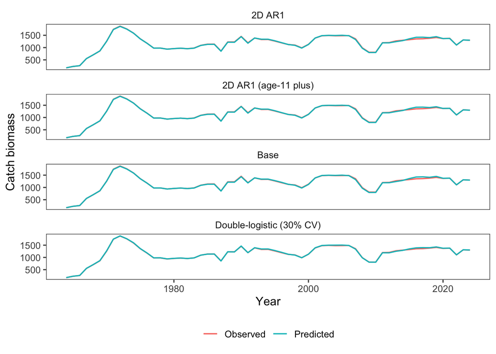

Figure 1: Observed vs predicted catch biomass by scenario (fishery).

## 2.2 Per-scenario assessment reports

For deeper inspection of each scenario (catch/SSB/selectivity surfaces/age-comp residuals), see the scenario-specific assessment pages:

- Base (form 0): `fishery_sel_form_0_assessment.html`
- Time-age varying double logistic (form 2): the stage-2 results documented on this page
- 2D AR1 (form 5): `fishery_sel_form_5_assessment.html`

# 3 Likelihood Component Comparison

## 3.1 Age-composition fit comparison

The model returns an age-composition negative log-likelihood contribution by fleet in `report$age_like`.

It also stores fishery observed (`oac_fsh`) and expected (`eac_fsh`) age-composition proportions by year×age in the saved run outputs.

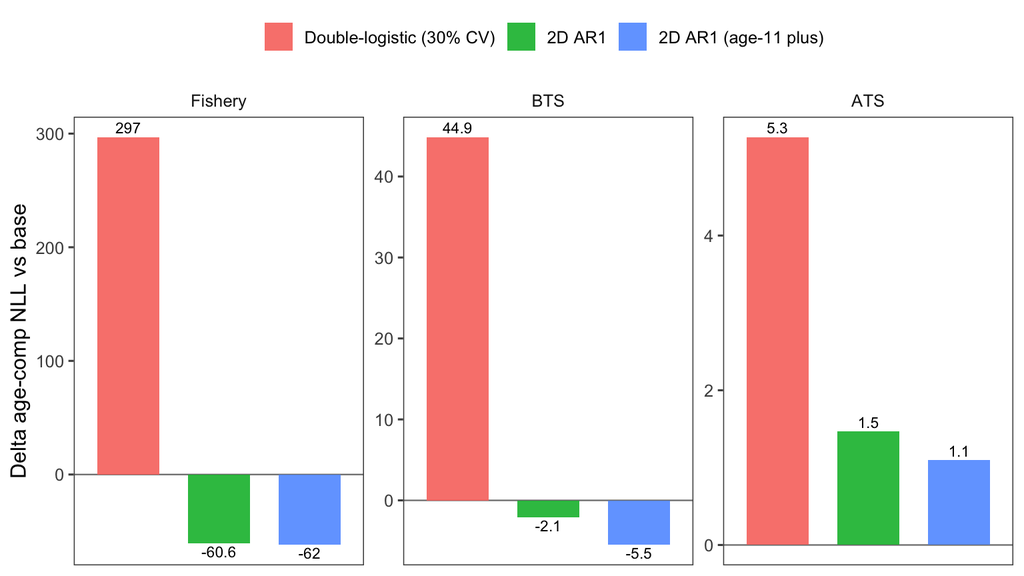

Figure 2: Change in age-composition NLL relative to the base scenario by fleet. Form 2 is the hierarchical double logistic with 30% process CV. These conditional fleet-specific likelihood contributions are comparable as data-fit diagnostics because they use the same observations and likelihood, but they are not marginal overall model objectives. Negative values indicate improved fit relative to base.

Table 2: Age-composition NLL contributions (and deltas vs base) by fleet and scenario.

| Fleet | Scenario | Age-composition NLL | Change from base |
| --- | --- | --- | --- |
| Fishery | Base | 157.8 | 0.0 |
| Fishery | Double-logistic (30% CV) | 454.8 | 297.0 |
| Fishery | 2D AR1 | 97.2 | -60.6 |
| Fishery | 2D AR1 (age-11 plus) | 95.8 | -62.0 |
| BTS | Base | 204.3 | 0.0 |
| BTS | Double-logistic (30% CV) | 249.2 | 44.9 |
| BTS | 2D AR1 | 202.2 | -2.1 |
| BTS | 2D AR1 (age-11 plus) | 198.8 | -5.5 |
| ATS | Base | 30.1 | 0.0 |
| ATS | Double-logistic (30% CV) | 35.4 | 5.3 |
| ATS | 2D AR1 | 31.6 | 1.5 |
| ATS | 2D AR1 (age-11 plus) | 31.2 | 1.1 |

## 3.2 One-step-ahead residual comparison

One-step-ahead (OSA) residuals provide a distribution-based check of the age-composition fits. The comparison uses `afscOSA` v0.0.1, multinomial residuals, the same observed compositions and effective sample sizes for every approach, and seed 202508. Each gear has one figure, with one column per fitted selectivity approach: base coefficients, the time-age varying double logistic with 30% process CV, the full-age 2D AR1 surface, and the age-11-plus 2D AR1 surface. The stage-1 shared curve was only an initialization step and is not treated as a competing assessment configuration.

The acoustic-trawl survey calculation uses ages 2–15. Its 2020 composition is omitted because restricting the data to those ages produces zero rounded observations; this rule is applied identically to all four approaches. As in the standard `afscOSA` plotting method, residuals outside +/-6 are capped in the figures only so the main patterns remain visible; their uncapped finite values are retained in the summary table.

Table 3: OSA residual summaries by gear and selectivity approach. The saved OSA metadata verifies that Form 2 is the hierarchical Stage 2 run with 30% process CV, random annual effects, and no old-age cap. SDNR is the standard deviation of the OSA residuals; values near 1 are consistent with the assumed residual scale. The last two columns give the percentage of absolute residuals exceeding 2 and 3.

| Gear | Approach | n | SDNR | Mean | Abs. > 2 (%) | Abs. > 3 (%) |
| --- | --- | --- | --- | --- | --- | --- |
| Fishery | Base coefficients | 840 | 0.87 | -0.06 | 3.1 | 0.6 |
| Fishery | Double-logistic (30% CV) | 840 | 1.22 | -0.08 | 10.0 | 3.0 |
| Fishery | 2D AR1 | 840 | 0.81 | -0.09 | 2.0 | 0.2 |
| Fishery | 2D AR1 (age-11 plus) | 840 | 0.80 | -0.04 | 2.3 | 0.2 |
| BTS | Base coefficients | 588 | 0.94 | -0.05 | 3.7 | 0.7 |
| BTS | Double-logistic (30% CV) | 588 | 1.01 | 0.18 | 5.3 | 0.5 |
| BTS | 2D AR1 | 588 | 0.94 | 0.04 | 3.9 | 0.7 |
| BTS | 2D AR1 (age-11 plus) | 588 | 0.93 | -0.02 | 4.1 | 0.7 |
| ATS | Base coefficients | 234 | 0.89 | 0.03 | 5.1 | 0.4 |
| ATS | Double-logistic (30% CV) | 234 | 0.92 | 0.11 | 5.6 | 0.4 |
| ATS | 2D AR1 | 234 | 0.90 | 0.05 | 4.7 | 0.4 |
| ATS | 2D AR1 (age-11 plus) | 234 | 0.90 | 0.04 | 4.7 | 0.4 |

The fishery comparison is the clearest separation among methods (Figure 3). The time-age varying double logistic has SDNR 1.22 and 10% of residuals outside +/-2, while the base, full-age 2D AR1, and age-11-plus 2D AR1 approaches remain closer to the reference scale (SDNR 0.87, 0.81, and 0.8). Differences are smaller for BTS (Figure 4), while all four approaches give similar ATS residual distributions (Figure 5). These diagnostics favor the more flexible fishery selectivity forms; they do not by themselves establish which configuration should be used for assessment.

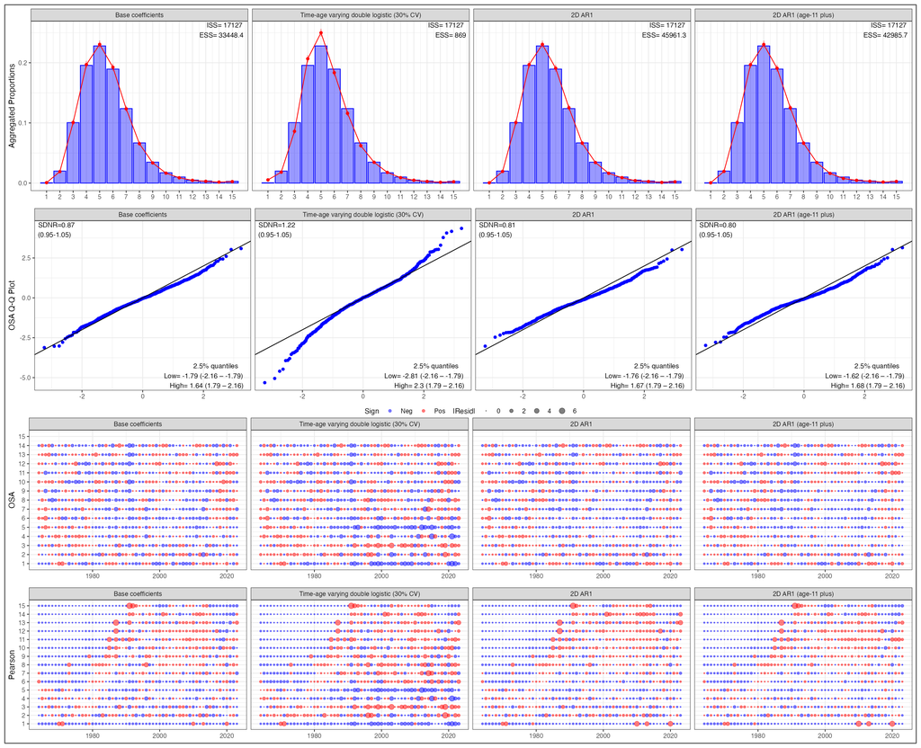

Figure 3: Fishery multinomial OSA comparison. Columns are the four fitted selectivity approaches; rows show aggregated fit, OSA Q-Q behavior, OSA residuals by age and year, and Pearson residuals. Values beyond +/-6 are capped in the figure only.

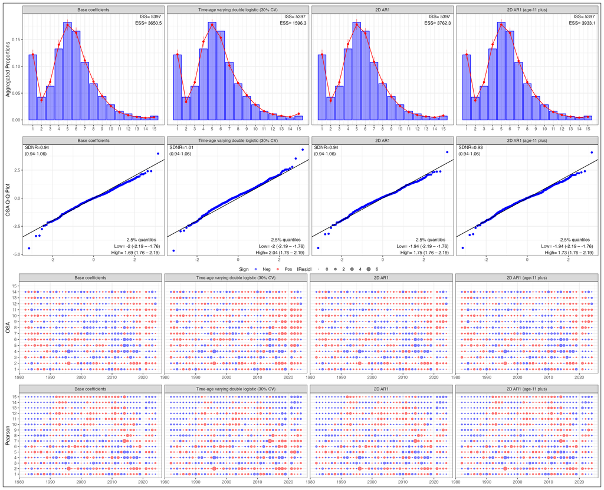

Figure 4: Bottom trawl survey multinomial OSA comparison, with one selectivity approach per column.

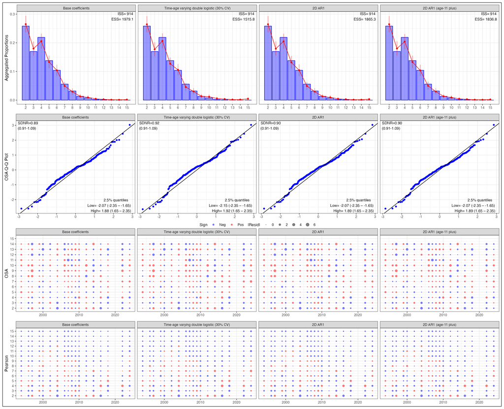

Figure 5: Acoustic-trawl survey multinomial OSA comparison for ages 2–15, with one selectivity approach per column. The 2020 composition has zero rounded observations after restricting to these ages and is omitted consistently.

## 3.3 Age Composition Fits

These figures follow the observed-versus-expected age-composition layout used for figures 5-7 in the main assessment report. Points show the observed proportions; colored lines show the expected proportions from each fishery selectivity scenario.

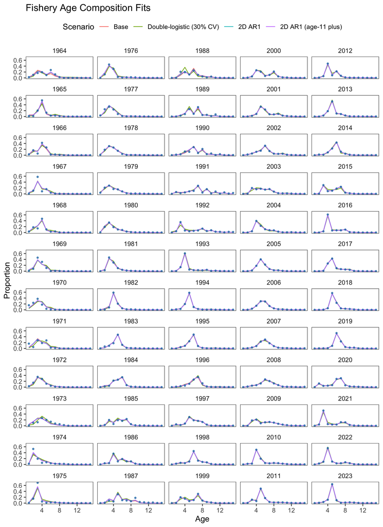

Figure 6: Observed and expected fishery age-composition patterns by fishery selectivity scenario, faceted by year. Points are observed proportions; lines are scenario-specific expected proportions.

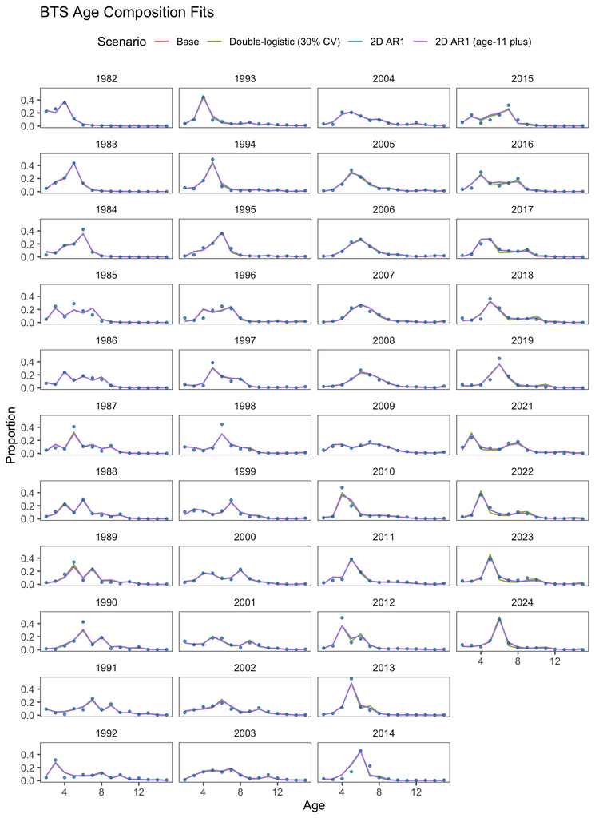

Figure 7: Observed and expected BTS age-composition patterns by fishery selectivity scenario, faceted by year. Points are observed proportions; lines are scenario-specific expected proportions.

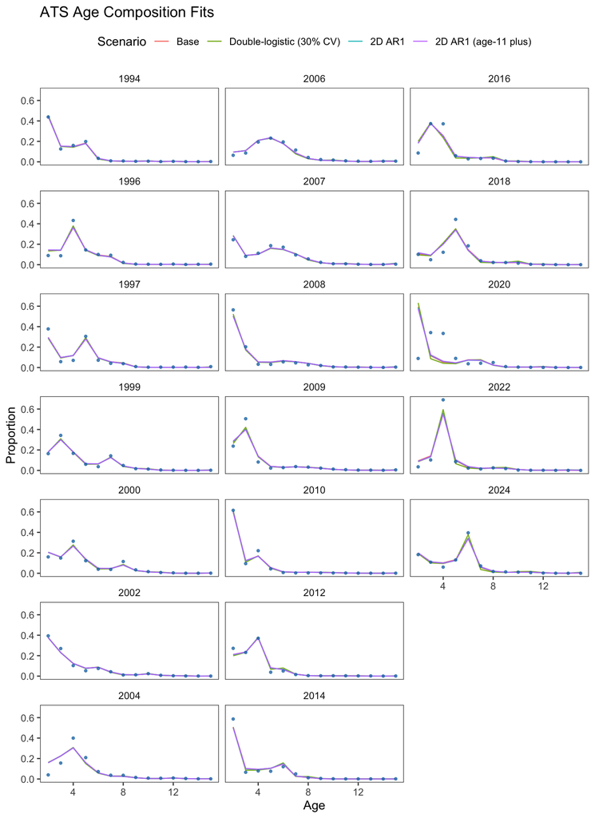

Figure 8: Observed and expected ATS age-composition patterns by fishery selectivity scenario, faceted by year. Points are observed proportions; lines are scenario-specific expected proportions.

The RTMB report object stores a set of likelihood (or penalty) components. The most relevant ones for this comparison are:

- `sel_like`, `sel_like_dev` (selectivity penalties)
- `age_like` (age composition likelihood)
- `cat_like` (catch fit)
- `cpue_like` (CPUE)

Table 4: Selected likelihood / penalty components returned in the RTMB report.

NLL components

| fishery_sel_form | label | sel_like | sel_like_dev | age_like_total | cat_like | cpue_like | avo_like | wt_like | nll | delta_nll | delta_sel_like | delta_sel_like_dev |
| --- | --- | --- | --- | --- | --- | --- | --- | --- | --- | --- | --- | --- |
| 0 | Base (coefficients + change-year deviations) | 17 | 192 | 392 | 3 | 1 | 9 | 6345 | 7075 | 0 | 0 | 0 |
| 2 | Time-age varying double logistic (30% CV) | 0 | 86 | 739 | 1 | 1 | 9 | 6345 | 7306 | 230 | -17 | -106 |
| 5 | 2D AR1 year×age (all years) | 0 | 79 | 331 | 2 | 1 | 9 | 6345 | 6883 | -192 | -17 | -113 |
| 6 | 2D AR1 ages 1–11; ages 12–15 fixed at age 11 | 0 | 121 | 326 | 2 | 1 | 9 | 6345 | 6918 | -157 | -17 | -71 |

# 4 Fishery Selectivity Surfaces

Fishery selectivity is represented as a relative age pattern that multiplies annual fully selected fishing mortality. Let $t$ index years, $a$ index ages, and $x_a = a + 0.5$ denote the age value used in the selectivity functions. Each form is converted to log selectivity $\ell_{t,a}$, centered within year, and exponentiated. The base and age-11-plus 2D AR1 runs constrain ages 11 and older to share the age-11 value:

$$\ell_{t,a} = \ell_{t,11}, \quad a \ge 11,$$

The time-age varying double logistic and full-age 2D AR1 do not impose this equality; their age effects are evaluated separately through age 15.

$$\ell^*_{t,a} =
\ell_{t,a} -
\log \left\{ A^{-1} \sum_{a=1}^{A} \exp(\ell_{t,a}) \right\},
\qquad
s_{t,a} = \exp(\ell^*_{t,a}).$$

The centered selectivity $s_{t,a}$ enters the population dynamics as $F_{t,a} = F_t s_{t,a}$. The HTML edition includes an implementation appendix with code references for reproducibility.

## 4.1 Literature context

Sampson (2014) provides a useful framing for this comparison by separating contact selection, availability, and population-level fishery selectivity. That distinction matters here because the RTMB selectivity surface is not simply a gear-retention curve; it is the relative fishing mortality pattern implied by the combined fishery, fleet behavior, fish distribution, and assessment model structure. The paper also illustrates that population selectivity can be temporally variable and can take diverse shapes, which motivates comparing the base change-year coefficient form against more flexible alternatives.

Punt et al. (2014) focuses on the assessment-model problem: selectivity forms reduce variance when they are parsimonious, but they can bias assessment outputs when the assumed functional form is wrong. The paper reviews how residual diagnostics, information criteria, and simulation studies can be used to evaluate selectivity choices. This report follows that logic by comparing model likelihood components, age-composition fits, selectivity surfaces, and spawning biomass trajectories rather than interpreting one selectivity form from the objective value alone.

Martell and Stewart (2014) is the most direct precedent for the time-varying selectivity comparison. Martell and Stewart used simulation-estimation experiments to evaluate fixed, blocked, and continuously changing selectivity patterns and emphasized that both statistical fit and policy consequences should be evaluated. The base model here resembles a blocked approach through change-year deviations, whereas the 2D AR1 option is closer to a continuous time-varying surface that borrows strength across neighboring years and ages.

Butterworth et al. (2014) asks how much selectivity uncertainty affects management advice across a set of applied assessment and management-procedure examples. The study is a caution against treating selectivity sensitivity as automatically dominant: selectivity can strongly affect reference points and biomass scale in some cases, but other uncertainties may be equally or more influential. For this report, that means SSB and likelihood differences should be read as one part of a broader sensitivity analysis rather than as a complete basis for model choice.

Cadrin et al. (2016) connects assessment selectivity and catchability to field observations of fishing gear, survey gear, efficiency, and availability. The paper is relevant because assessment-estimated selectivity can absorb several processes that field studies may measure separately. For EBS pollock, any interpretation of the fishery selectivity surface should therefore distinguish model-based population selectivity from direct observations about gear performance, fishing behavior, or fish availability.

Vasilakopoulos et al. (2020) shifts the focus from estimating selectivity curves to operational metrics for management advice. The authors evaluate candidate metrics for sensitivity to selectivity changes and robustness to recruitment and fishing-mortality variation, identifying the ratio of fishing mortality on the first recruited age to average fishing mortality as a useful summary. That perspective suggests a practical extension of this comparison: after fitting alternative selectivity forms, summarize whether the implied exploitation pattern changes in a way that managers could track, not only whether the full selectivity surface looks different.

## 4.2 Form 0: base coefficients with change-year deviations

The base EBS pollock form follows the statistical approach developed by Butterworth et al. (2003), which placed catch-at-age fitting in a likelihood framework and allowed age-specific selectivity to change over time within a specified structure. That paper is the key methodological reference for the assessment’s use of age coefficients with time-varying deviations.

The implemented base model uses estimated age coefficients plus deviations at configured fishery-selectivity change years:

$$\ell_{t,a} = c_a + d_{k(t),a},$$

where $c_a$ is the baseline age coefficient and $d_{k(t),a}$ is the deviation for the change-year block $k(t)$. This form is flexible at the configured break points but does not estimate a continuous year-to-year process for fishery selectivity.

## 4.3 Form 2: time-age varying double logistic

The double-logistic curve is generated from positive parameters $p_{1,t}$, $p_{2,t}$, and $p_{3,t}$. The model estimates their logarithms, so $p_{j,t}=\exp(\theta_{t,j})$. The initial values on the natural scale are 1.5, 3, and 4. These parameters define the ascending and descending transition ages:

$$\gamma_{1,t} = p_{1,t} + p_{2,t},
\qquad
\gamma_{2,t} = 2p_{1,t} + p_{2,t} + p_{3,t}.$$

The two logistic limbs are

$$u_{t,a} =
\left[1 + \exp\left\{-\log(19)\frac{x_a - \gamma_{1,t}}{p_{1,t}}\right\}\right]^{-1},$$

$$v_{t,a} =
1 -
\left[1 + \exp\left\{-\log(19)\frac{x_a - \gamma_{2,t}}{p_{3,t}}\right\}\right]^{-1},$$

Following the EBS pollock prior-elicitation formulation, the raw curve is

$$s^{\mathrm{hard}}_{t,a} =
\min\left\{1,\;u_{t,a}v_{t,a}0.95^{-2}\right\}.$$

The literal minimum has a kink where its two arguments meet. The RTMB implementation therefore uses the differentiable approximation

$$s_{t,a} = 1 - \frac{\log\left[1+\exp\{\kappa(1-r_{t,a})\}\right]}{\kappa}
+ \frac{\log\{1+\exp(-\kappa)\}}{\kappa},
\qquad r_{t,a}=u_{t,a}v_{t,a}0.95^{-2},\quad \kappa=50.$$

This transform is zero at zero, approaches one smoothly, and closely follows the hard cap except immediately around $r_{t,a}=1$. Define $b_{t,a}=\log(s_{t,a}+\epsilon)$.

It is then centered so arithmetic mean selectivity within each year is one:

$$\ell_{t,a} = b_{t,a} -
\log\left\{\frac{1}{A}\sum_{a'=1}^{A}\exp(b_{t,a'})\right\}.$$

An earlier implementation subtracted $\max_a b_{t,a}$ before this centering. That subtraction was unnecessary: centering removes any common additive constant, so $\operatorname{center}(b-\max b)=\operatorname{center}(b)$ apart from numerical roundoff. It was removed because `max()` is not differentiable when the age attaining the maximum changes. The standard implementation then sets ages 11 and older equal to the age-11 value and centers the result again; the uncapped sensitivity below omits that equality constraint.

The original annual fixed-effect implementation estimated one log-scale triplet $\theta_t = (\log p_{1,t},\log p_{2,t},\log p_{3,t})$ for every year. It used shrinkage toward $\mu_0 = \log(1.5,3,4)$ and a first-difference penalty:

$$Q_\mathrm{fixed} =
\sum_t \sum_j
\left(\frac{\theta_{t,j} - \mu_{0,j}}{\sigma_{p,j}}\right)^2
+
\frac{1}{2}
\sum_{t=2}^{T} \sum_j
\left(\frac{\theta_{t,j} - \theta_{t-1,j}}{\sigma_{\Delta,j}}\right)^2,$$

where $\sigma_p = (0.75,0.75,0.45)$ and $\sigma_\Delta = (0.60,0.60,0.40)$. This is the 183-parameter formulation that failed the convergence checks; it is retained here to document that attempt, not as the formulation used for the corrected stage-2 results.

The successful staged formulation does not use the first-difference term above. Stage 1 estimates a single mean triplet $\mu$ shared across years, with

$$Q_1 =
\sum_j
\left(\frac{\mu_j-\mu_{0,j}}{\sigma_{p,j}}\right)^2.$$

Stage 2 defines the annual log-scale parameters as

$$\theta_t = \mu + \delta_t,
\qquad
\delta_{t,j} \overset{\mathrm{iid}}{\sim}
\mathcal{N}(0,\sigma_{\mathrm{CV}}^2),
\qquad
\sigma_{\mathrm{CV}} = \sqrt{\log(1+0.30^2)} = 0.2936.$$

Ignoring normalizing constants, the corresponding penalty is

$$Q_2 =
\sum_j
\left(\frac{\mu_j-\mu_{0,j}}{\sigma_{p,j}}\right)^2
+
\frac{1}{2\sigma_{\mathrm{CV}}^2}
\sum_t\sum_j \delta_{t,j}^2.$$

The code evaluates the random-effect contribution with the full normal log density and integrates the annual deviations using RTMB’s Laplace approximation. The current section-2.6 implementation retains the configured across-age curvature penalty but omits the historical old-age shape penalty. The smaller prior scale for the third mean parameter provides stronger shrinkage on the descending limb, which is otherwise weakly informed by older ages.

### 4.3.1 Development history and reproducibility

The initial option-2 fit should be treated as a convergence diagnosis rather than as a candidate assessment result. It estimated 61 annual parameter triplets, or 183 double-logistic parameters. The saved run ended with optimizer code 1 (`false convergence (8)`) and a maximum absolute gradient of 1.8366. Its objective value was 8299.2 and agreed with the independently evaluated reported total to numerical precision. Thus, the objective was evaluated consistently, but the parameter estimates do not yet satisfy the convergence standard needed for biological or assessment interpretation.

**ImportantResult of the staged tests**

The originally implemented annual fixed-effect option failed, but the corrected two-stage section-2.6 formulation converged. A shared three-parameter curve was estimated first, followed by zero-centered annual random effects with a fixed 30% CV. The selected stage-2 fit had a marginal gradient of 0.000064. After two unused parameters were removed, the stage-2 Hessian was positive definite and finite standard errors were obtained.

The selectable-form implementation and the exact September 2025 ADMB–RTMB bridge now coexist on `main`, with the bridge behavior protected by regression tests. The former experiment branch remains on GitHub as a recovery point, but a separate worktree is no longer needed to reproduce the accepted fit.

#### 4.3.1.1 Step 1: update and verify the primary checkout

From the repository containing this report:

```bash
git fetch --all --prune
git switch main
git pull --ff-only
Rscript tests/test_sept_2025_bridge.R
Rscript tests/test_double_logistic_form2.R
```

Scenario-specific files are written under `analysis/output/corrected_full_age_bts/double_logistic_experiments/`. Each fit retains its starting rule, prior scales, seed, objective, gradient, bounds check, and Hessian check.

#### 4.3.1.2 Step 2: reproduce the original result

The unchanged configuration was reproduced with the dedicated experiment runner:

```bash
POLLOCK_ROOT=/path/to/pollock \
  Rscript R/run_double_logistic_experiments.R
```

The reproduction matched the saved objective (8299.1812) and maximum gradient (1.8366), including the `false convergence (8)` message. The objective and independently evaluated report differed by less than $4\times10^{-12}$. Restarting did not resolve the gradient, confirming the original result rather than an input or reporting mismatch.

#### 4.3.1.3 Step 3: improve starting values

The two-stage test was implemented as follows:

1. Fit one common double-logistic triplet to all years.
2. Replicate that fitted triplet across the 61 years.
3. Use the resulting matrix as the starting point for the annual option-2 fit.
4. Restart the annual fit from its solution and check whether the gradient decreases further.

This preliminary equality-mapped curve converged with objective 9101.7 and maximum gradient 0.0005. Because its prior contribution was repeated for every year, it was useful as a starting-value diagnostic but was not the intended three-parameter model. The corrected shared-parameter fit is reported in step 6. When the preliminary triplet was expanded across years, the annual fit returned objective 8299.0, maximum gradient 1.7937, and false convergence. Better initialization therefore helped only slightly and identifies the annual parameterization—not the common double-logistic shape—as the main difficulty.

#### 4.3.1.4 Step 4: test modestly informative regularization

After establishing the improved-start baseline, replace the original scales with the proposed moderately stronger values

$$\sigma_p = (0.50, 0.50, 0.35), \qquad
\sigma_\Delta = (0.25, 0.25, 0.20).$$

The first set controls shrinkage of annual log parameters toward the central double-logistic shape; the second controls year-to-year changes. The proposed scales produced objective 8383.5 and maximum gradient 14.5524. Scale multipliers of 0.75, 1.25, and 1.50 also failed, with maximum gradients of 15.0113, 2.7645, and 4.9645, respectively. The proposed stronger regularization did not achieve estimability.

#### 4.3.1.5 Step 5: use multiple starting points

For both the original and proposed regularization, 10 reproducible starts were generated by applying small log-scale perturbations to the common-curve solution. All results, including failures, were retained. Under the original scales, objectives ranged from 8298.0 to 8299.5 and gradients from 1.8158 to 12.8581. Under the proposed scales, objectives ranged from 8383.3 to 8383.7 and gradients from 6.6320 to 14.6955. All 20 fits returned false convergence. The variation among endpoints, together with persistent large gradients, is consistent with weak identification and local irregularity rather than a single poor starting point.

#### 4.3.1.6 Step 6: consider a hierarchical RTMB formulation

The intended model is not the original annual matrix treated directly as 183 random effects. It is a two-stage hierarchical parameterization:

1. Estimate one log-scale triplet $\mu=(\mu_1,\mu_2,\mu_3)$ shared by all fishery years.
2. Starting from that estimate, define each annual triplet as $\theta_t=\mu+\delta_t$.
3. Treat the annual deviations $\delta_t$ as zero-centered random effects.
4. Fix their log-scale standard deviation to $\sqrt{\log(1+0.30^2)}=0.2936$, corresponding to a 30% lognormal CV.
5. Integrate the annual deviations with the RTMB Laplace approximation while continuing to estimate the shared mean triplet and the other assessment parameters.

The final stage-2 mean parameters on the natural scale were $p_1=1.403$, $p_2=2.861$, and $p_3=5.981$. The marginal fit terminated with optimizer code 0 and maximum gradient 0.000064.

The fitted annual modes had across-year standard deviations of 0.294, 0.238, and 0.249 on the log scale for $p_1$, $p_2$, and $p_3$, respectively. These correspond to realized across-year CVs of approximately 30.0%, 24.1%, and 25.3%. They need not equal the 30% distributional CV because they are conditional modes informed jointly by the data and the random-effect distribution.

Table 5: Selected 30% CV hierarchical option-2 fit. The optimizer objective is Laplace marginal; the evaluated total is the conditional joint NLL at the fitted random-effect modes.

| Configuration | Marginal objective | Conditional joint NLL | Optimizer code | Maximum gradient | Positive Hessian | Finite standard errors | Elapsed seconds |
| --- | --- | --- | --- | --- | --- | --- | --- |
| 30% CV annual random effects | 7592.6 | 7305.6 | 0 | 6.4e-05 | TRUE | TRUE | 167.1 |

#### 4.3.1.7 Section-2.6 formulation without the age-11-and-older equality

The preferred option-2 experiment now follows the three-parameter function on the [selectivity prior-elicitation page](https://jimianelli.github.io/selex/): the product of the ascending and descending limbs is smoothly capped near one, ages 11–15 are not forced to share the age-11 value, and the associated nonsmooth old-age shape penalty is omitted.

This is time-and-age variation through a parsimonious curve rather than a free year-by-age surface: the three annual parameters move the ascending limb, peak, and descending limb, thereby changing selectivity across ages each year. There is no additional independent random effect for every age; that more flexible structure is represented by the 2D AR1 alternative.

The stage-2 mean parameters were $p_1=1.40$, $p_2=2.86$, and $p_3=5.98$. Selectivity declined smoothly after age 11; in 2024 its values at ages 11–15 were 1.169, 0.961, 0.753, 0.564, and 0.406 after within-year centering.

The earlier zero-eigenvalue warning was not created by these three selectivity parameters. Two unused temperature-residual parameters, `resid_temp_x1` and `resid_temp_x2`, had inadvertently remained in the experimental parameter vector even though neither appears in the objective. Perturbing either from -10 to +10 changed the objective by exactly zero. The 623-parameter Hessian therefore had two numerical-zero eigenvalues and no substantively negative eigenvalues. After mapping those unused parameters out, the current 621-parameter stage-2 Hessian is positive definite: its minimum eigenvalue is 0.1349 and finite standard errors are obtained.

Table 6: Option-2 comparison. The current section-2.6 implementation uses a smooth approximation to the cap at one, does not impose the age-11-and-older equality, and maps two unused temperature-residual parameters out of the optimization. Earlier capped rows are retained only as historical context. Stage-2 objectives are Laplace marginal objectives and should be compared only with other stage-2 rows.

| Configuration | Stage | Objective | Evaluated total | Fishery age NLL | Maximum gradient | p1 | p2 | p3 | Positive Hessian | Finite standard errors |
| --- | --- | --- | --- | --- | --- | --- | --- | --- | --- | --- |
| Earlier ages-11+ formulation | Shared curve | 8659.1 | 8659.1 | 1220.6 | 0.00072 | 1.65 | 3.27 | 9.43 | FALSE | FALSE |
| Earlier ages-11+ formulation | Annual random effects | 8728.2 | 8293.4 | 790.3 | 0.00027 | 1.49 | 3.23 | 11.49 | FALSE | FALSE |
| Smooth section-2.6 formulation | Shared curve | 8653.0 | 8653.0 | 1222.7 | 0.00045 | 1.67 | 3.29 | 7.20 | TRUE | TRUE |
| Smooth section-2.6 formulation | Annual random effects | 8482.6 | 8173.4 | 498.8 | 0.00007 | 1.41 | 2.94 | 6.16 | TRUE | TRUE |

The earlier smallest Hessian eigenvalues, about $-1.2\times10^{-16}$ and $-1.9\times10^{-16}$, were numerical zeros rather than meaningful negative curvature. They corresponded to the unused `resid_temp_x1` and `resid_temp_x2` parameters. Once those were mapped out, the current stage-2 minimum eigenvalue was 0.1349 and all standard errors were finite.

#### 4.3.1.8 Step 7: decide whether a fit is usable

Each experiment should pass all of the following checks before its assessment results are compared:

- optimizer convergence code 0;
- maximum absolute gradient below 0.001, with 0.0001 preferred;
- no important parameters at or very near their bounds;
- positive-definite Hessian and finite standard errors;
- objective value matching the independently evaluated reported total;
- stable results when optimization is restarted from the fitted values;
- similar solutions across reasonable starting points;
- smooth, biologically plausible annual parameter paths and selectivity curves;
- understandable changes in likelihood components, age-composition residuals, spawning biomass, recruitment, and fishing mortality; and
- conclusions that remain similar across modest changes in prior strength.

The lower objective value is only one diagnostic. Convergence, stability, biological plausibility, fit to the observed compositions, and effects on assessment quantities should be considered together.

Table 7: Selected option-2 convergence experiments. Objective is the minimized total negative log likelihood; max gradient is the largest absolute element of the objective gradient; a positive Hessian is required for a locally stable solution.

| Scenario | Objective | Optimizer code | Max gradient | At bounds | Positive Hessian |
| --- | --- | --- | --- | --- | --- |
| Original reproduction | 8299.2 | 1 | 1.8366 | 0 | FALSE |
| Pooled three-parameter fit | 9101.7 | 0 | 0.0005 | 0 | FALSE |
| Annual fit from pooled start | 8299.0 | 1 | 1.7937 | 0 | FALSE |
| Proposed stronger prior | 8383.5 | 1 | 14.5524 | 0 | FALSE |
| Proposed scales × 0.75 | 8453.8 | 1 | 15.0113 | 0 | FALSE |
| Proposed scales × 1.25 | 8338.6 | 1 | 2.7645 | 0 | FALSE |
| Proposed scales × 1.50 | 8306.0 | 1 | 4.9645 | 0 | FALSE |

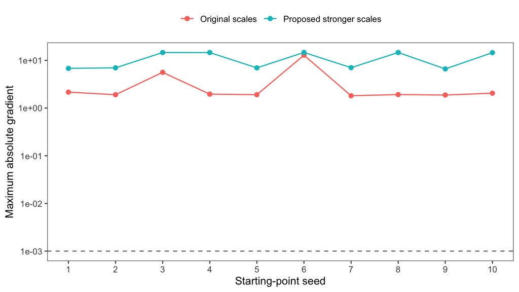

Figure 9: Maximum absolute gradients from 10 perturbed starts under each regularization. The dashed line marks the 0.001 acceptance threshold; every annual fit remained well above it.

| Stage | Configuration | Status | Result |
| --- | --- | --- | --- |
| Original fit | Original starts and scales | Completed | Code 1; gradient 1.8366; objective 8299.2; not usable for interpretation |
| Reproduction and restart | Unchanged model, then restart from saved solution | Completed | Reproduced false convergence; restart did not improve it |
| Common-curve initialization | Pooled triplet followed by annual fit | Completed | Pooled fit passed the gradient criterion; annual fit failed |
| Modestly informative scales | $\sigma_p=(0.50,0.50,0.35)$, $\sigma_\Delta=(0.25,0.25,0.20)$ | Completed | False convergence; gradient 14.5524 |
| Prior sensitivity | Scale multipliers 0.75, 1.25, and 1.50 | Completed | All three failed convergence and Hessian checks |
| Multiple starts | 10 original-prior and 10 proposed-prior perturbations | Completed | All 20 returned false convergence |
| Preliminary random-effects sensitivity | Existing absolute annual matrix integrated directly | Completed | Failed in RTMB’s inner Newton optimization; this was not the intended hierarchy |
| Corrected stage 1 | Smooth section-2.6 curve shared across all years | Completed | Code 0; gradient 0.00045; positive Hessian |
| Corrected stage 2 | Smooth section-2.6 mean triplet plus annual random deviations with 30% CV | Completed | Code 0; marginal gradient 0.000064 |
| Uncertainty check | Hessian and standard errors after mapping unused parameters out | Completed | Minimum eigenvalue 0.1354; finite standard errors obtained |

Taken together, the tests reject the 183-parameter annual fixed-effect version but support continued evaluation of the smooth section-2.6 30% CV random-effects model. The next step is to compare its residuals and assessment trajectories with the base and 2D AR1 alternatives.

**NoteDouble-logistic estimability**

The failed run described above estimated 183 unrelated annual fixed effects. It has been superseded by the two-stage hierarchical fit shown here. In the selected Stage 2 sensitivity, the annual deviations are random effects with a fixed 30% process CV around the shared three-parameter mean curve. This fit passed the optimizer, gradient, Hessian, and finite-standard-error checks.

## 4.4 Forms 5 and 6: 2D AR1 time-varying surfaces

The full-age 2D AR1 form estimates a year-by-age latent field $z_{t,a}$ for ages 1–15. The age-11-plus configuration estimates the same field only for ages 1–11 and deterministically sets ages 12–15 equal to age 11 before within-year centering. Before centering, the estimated-age log selectivity is

$$\ell_{t,a} = z_{t,a},$$

The latent field is penalized with a separable AR1 process over year and its estimated ages:

$$z \sim \operatorname{AR1}_{\mathrm{year}}(\rho_y)
\otimes
\operatorname{AR1}_{\mathrm{age}}(\rho_a),$$

with fitted correlations reported in the caption for Figure 10. The scenario recipe down-weights the AR1 penalty relative to the default, allowing more interannual variation while still borrowing strength across neighboring years and ages.

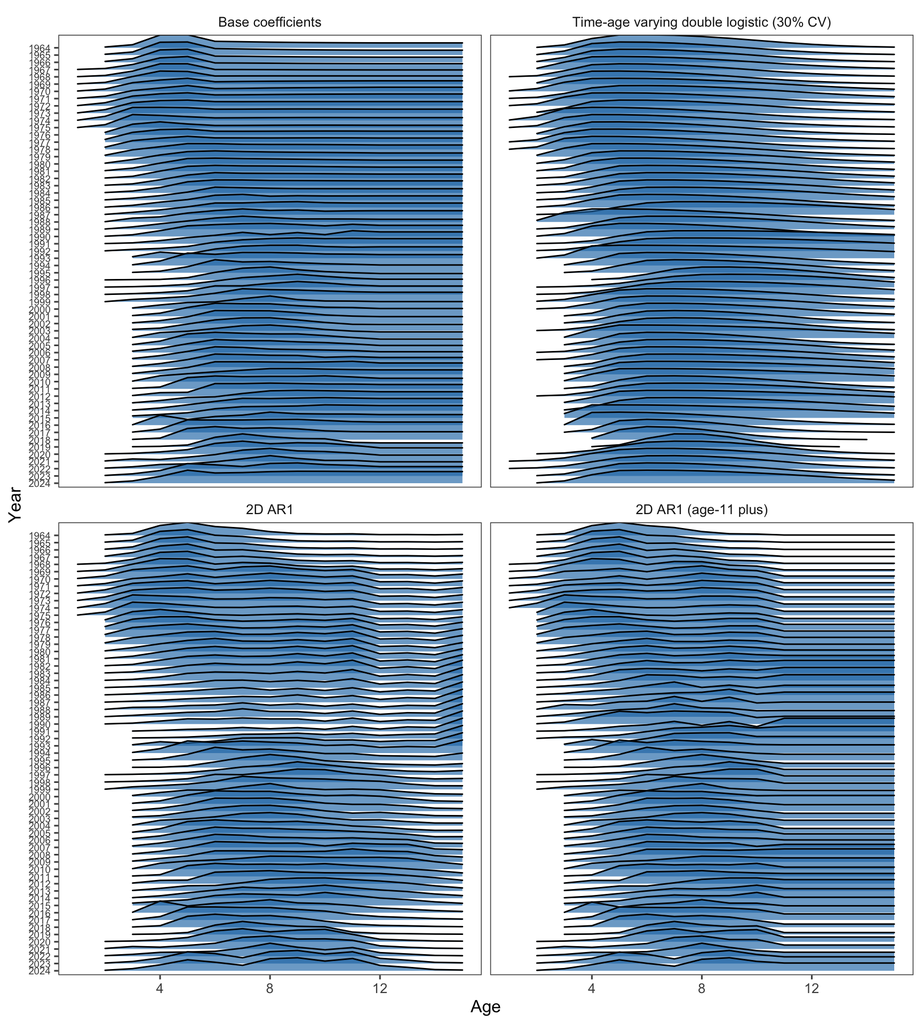

Figure 10: Fishery selectivity through time (ggridges), normalized within year. The time-age varying double logistic is the stage-2 fit: annual random deviations around a shared mean curve with 30% process CV, a differentiable cap near one, and no age-11-and-older equality. Stage 1 was used only to initialize this fit and is not displayed. The stage-2 fit passed the optimizer, gradient, positive-Hessian, and finite-standard-error checks. For the 2D AR1 form, fitted correlations are rho_y = 0.990 and rho_a = 0.366.

# 5 Spawning Biomass Comparison

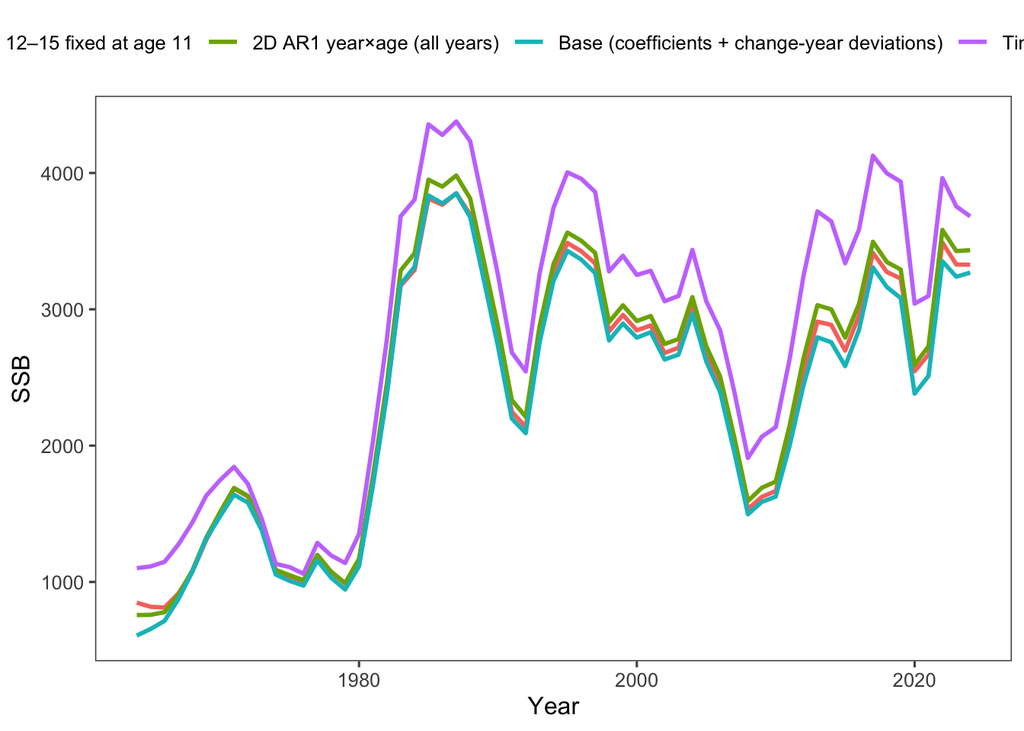

Figure 11: Spawning biomass (SSB) trajectories by fishery selectivity form.

Table 8: SSB differences relative to base run at key years.

SSB deltas vs base

| label | fishery_sel_form | year | SSB | delta_SSB | pct_delta |
| --- | --- | --- | --- | --- | --- |
| Base (coefficients + change-year deviations) | 0 | 2000 | 2791.918 | 0.0000 | 0.0000 |
| Time-age varying double logistic (30% CV) | 2 | 2000 | 3251.809 | 459.8914 | 16.4722 |
| 2D AR1 year×age (all years) | 5 | 2000 | 2914.053 | 122.1349 | 4.3746 |
| 2D AR1 ages 1–11; ages 12–15 fixed at age 11 | 6 | 2000 | 2845.919 | 54.0014 | 1.9342 |
| Base (coefficients + change-year deviations) | 0 | 2010 | 1626.073 | 0.0000 | 0.0000 |
| Time-age varying double logistic (30% CV) | 2 | 2010 | 2135.417 | 509.3437 | 31.3235 |
| 2D AR1 year×age (all years) | 5 | 2010 | 1736.572 | 110.4982 | 6.7954 |
| 2D AR1 ages 1–11; ages 12–15 fixed at age 11 | 6 | 2010 | 1667.581 | 41.5081 | 2.5527 |
| Base (coefficients + change-year deviations) | 0 | 2020 | 2381.126 | 0.0000 | 0.0000 |
| Time-age varying double logistic (30% CV) | 2 | 2020 | 3041.561 | 660.4354 | 27.7363 |
| 2D AR1 year×age (all years) | 5 | 2020 | 2592.103 | 210.9767 | 8.8604 |
| 2D AR1 ages 1–11; ages 12–15 fixed at age 11 | 6 | 2020 | 2545.285 | 164.1591 | 6.8942 |
| Base (coefficients + change-year deviations) | 0 | 2023 | 3238.676 | 0.0000 | 0.0000 |
| Time-age varying double logistic (30% CV) | 2 | 2023 | 3754.709 | 516.0322 | 15.9334 |
| 2D AR1 year×age (all years) | 5 | 2023 | 3427.318 | 188.6413 | 5.8246 |
| 2D AR1 ages 1–11; ages 12–15 fixed at age 11 | 6 | 2023 | 3328.523 | 89.8464 | 2.7742 |
| Base (coefficients + change-year deviations) | 0 | 2024 | 3269.154 | 0.0000 | 0.0000 |
| Time-age varying double logistic (30% CV) | 2 | 2024 | 3681.787 | 412.6333 | 12.6220 |
| 2D AR1 year×age (all years) | 5 | 2024 | 3433.442 | 164.2887 | 5.0254 |
| 2D AR1 ages 1–11; ages 12–15 fixed at age 11 | 6 | 2024 | 3327.225 | 58.0716 | 1.7763 |

# 6 Appendix: Implementation References

The equations above are implemented through the RTMB parameter builder, the selectivity construction helper, and the model likelihood. These references provide traceability without repeating the methods section.

## 6.1 Parameter blocks

Fishery selectivity parameters are initialized in `R/utils-rtmb.R::add_fishery_selectivity_parameters()`. The defaults to check first are in `R/utils-rtmb.R:223-235`:

```r
add_fishery_selectivity_parameters <- function(parameters, data) {
  nyrs <- as.integer(data$endyr - data$styr + 1L)
  nages <- as.integer(data$nages)
  defaults <- list(
    sel_double_logistic_fsh = matrix(log(c(1.5, 3, 4)), nrow = nyrs, ncol = 3, byrow = TRUE),
    sel_double_logistic_mean_fsh = log(c(1.5, 3, 4)),
    sel_double_logistic_dev_fsh = matrix(0, nrow = nyrs, ncol = 3),
    sel_tv_ar1_fsh = matrix(0, nrow = nyrs, ncol = nages),
    sel_tv_ar1_rho_fsh = c(0, 0),
    log_sel_tv_ar1_sigma_fsh = log(0.2)
  )
}
```

`R/Rpm.R:9-22` contains matching safety defaults. These matter when older saved parameter lists are evaluated without the newer optional selectivity blocks:

```r
if (!exists("fishery_sel_form", inherits = FALSE)) fishery_sel_form <- 0L
if (!exists("sel_double_logistic_mean_fsh", inherits = FALSE))
  sel_double_logistic_mean_fsh <- log(c(1.5, 3, 4))
if (!exists("sel_double_logistic_dev_fsh", inherits = FALSE))
  sel_double_logistic_dev_fsh <- matrix(0, endyr - styr + 1L, 3)
if (!exists("sel_double_logistic_cv", inherits = FALSE))
  sel_double_logistic_cv <- 0.20
if (!exists("fishery_sel_old_age_cap", inherits = FALSE))
  fishery_sel_old_age_cap <- 0L
if (!exists("sel_tv_ar1_fsh", inherits = FALSE)) sel_tv_ar1_fsh <- matrix(0, nrow = endyr - styr + 1, ncol = nages)
if (!exists("sel_tv_ar1_rho_fsh", inherits = FALSE)) sel_tv_ar1_rho_fsh <- c(0, 0)
if (!exists("log_sel_tv_ar1_sigma_fsh", inherits = FALSE)) log_sel_tv_ar1_sigma_fsh <- log(0.2)
if (!exists("sel_tv_ar1_weight_fsh", inherits = FALSE)) sel_tv_ar1_weight_fsh <- 1.0
```

## 6.2 Selectivity construction

The base coefficient form is built in `R/model_funs.R:20-61`. The initial coefficients are centered, change-year deviations are applied, and selectivity is carried forward in years without a change:

```r
log_sel[1, 1:nsel] <- coffs
log_sel[1, (nsel + 1):nages] <- coffs[nsel]
log_sel[1, ] <- log_sel[1, ] - log(mean(exp(log_sel[1, ])))

if (ii <= nch_fsh && year == yrs_ch_fsh[ii]) {
  log_sel[i + 1, 1:nsel] <- log_sel[i, 1:nsel] + sel_devs[ii, ]
  log_sel[i + 1, (nsel + 1):nages] <- log_sel[i + 1, nsel]
} else {
  log_sel[i + 1, ] <- log_sel[i, ]
}
```

`cap_old_age_log_selectivity()` implements the optional age-11 plus-group constraint used by forms that request it. The accepted Form 2 run passes `old_age_cap = 0L`, so this block is not applied to its surface:

```r
if (ncol(log_sel) >= first_old_age) {
  for (i in seq_len(nrow(log_sel))) {
    log_sel[i, first_old_age:ncol(log_sel)] <- log_sel[i, first_old_age]
    if (isTRUE(center)) log_sel[i, ] <- center_log_selectivity(log_sel[i, ])
  }
}
```

`R/model_funs.R:102-180` dispatches among selectivity forms and returns the year-by-age log selectivity matrix. The most relevant branches for this comparison are `R/model_funs.R:117-123` for form 0, `R/model_funs.R:136-153` for form 2, and `R/model_funs.R:172-180` for form 5:

```r
if (form == 0L) {
  out <- compute_selectivity_fsh(...)
  out$log_sel <- cap_old_age_log_selectivity(out$log_sel, first_old_age = 11L)
  return(out)
} else if (form == 2L) {
  effective <- sel_double_logistic_dev_fsh
  for (i in seq_len(nrow(effective)))
    for (j in seq_len(ncol(effective)))
      effective[i, j] <- sel_double_logistic_mean_fsh[j] +
        sel_double_logistic_dev_fsh[i, j]
  out <- compute_selectivity_fsh_double_logistic(
    stsel = styr, endyr = endyr, nages = nages,
    parameters = effective, old_age_cap = 0L
  )
} else if (form == 5L) {
  for (i in 1:nyrs) log_sel[i, ] <- center_log_selectivity(sel_tv_ar1_fsh[i, ])
}
```

Inside `compute_selectivity_fsh_double_logistic()`, the product of the two logistic limbs is passed through a differentiable soft cap near one and then centered within year. Form 2 does not apply the age-11-and-older equality.

`R/Rpm.R` then exponentiates the returned log selectivity and applies it inside the annual fishing mortality calculation:

```r
sel_fsh <- exp(log_sel_fsh)
F[i, ] <- Fmort[i] * sel_fsh[i, ]
```

Thus, all scenario differences shown in the comparison report enter through the same population-dynamics pathway after the selectivity surface has been constructed.

## 6.3 Selectivity penalties

`R/Rpm.R` dispatches to the hierarchical Form 2 penalty after the age-composition likelihood and before survey selectivity penalties:

```r
pen_fsh <- selectivity_like_fsh_double_logistic(
  log_sel_fsh = log_sel_fsh,
  selCFsh = selCFsh,
  domFish = domFish,
  mean_parameters = sel_double_logistic_mean_fsh,
  annual_deviations = sel_double_logistic_dev_fsh,
  prior_scale = sel_double_logistic_prior_scale,
  process_cv = sel_double_logistic_cv,
  old_age_cap = fishery_sel_old_age_cap
)
```

For form 2, `selectivity_like_fsh_double_logistic()` applies a prior to the shared mean triplet and a normal density to the annual deviations. The selected sensitivity fit fixes the process CV at 30%:

```r
target <- log(c(1.5, 3, 4))
dev <- dev + sum(((mean_parameters - target) / prior_scale)^2)
log_sd <- sqrt(log(1 + process_cv^2))
dev <- dev - sum(dnorm(annual_deviations, 0, log_sd, log = TRUE))
```

For form 5, `R/model_funs.R:827-841` transforms the AR1 correlations, applies the old-age constraint to the latent field used in the penalty, and evaluates the separable AR1-by-AR1 density:

```r
rho_y <- safe_logit_rho(sel_tv_ar1_rho_fsh[1])
rho_a <- safe_logit_rho(sel_tv_ar1_rho_fsh[2])
f_year <- function(x) dautoreg(x, phi = rho_y, log = TRUE)
f_age <- function(x) dautoreg(x, phi = rho_a, log = TRUE)
sel_tv_ar1_fsh_pen <- cap_old_age_log_selectivity(
  sel_tv_ar1_fsh,
  first_old_age = 11L,
  center = FALSE
)
dev <- dev - sel_tv_ar1_weight_fsh * dseparable(f_year, f_age)(sel_tv_ar1_fsh_pen, scale = scale)
```

## 6.4 Scenario driver

`R/run_fishery_selectivity_forms.R` defines the base and 2D AR1 fits. `R/run_double_logistic_experiments.R` defines the two-stage Form 2 fit. Its selected Stage 2 sensitivity setup is:

```r
data$fishery_sel_form <- 2L
data$sel_double_logistic_hierarchical <- 1L
data$sel_double_logistic_cv <- 0.30
data$fishery_sel_old_age_cap <- 0L
random <- "sel_double_logistic_dev_fsh"
obj <- RTMB::MakeADFun(rpm, parms, map = map_obj, data = data, random = random)
```

The report reads base and AR1 objects from `analysis/output/corrected_full_age_bts/fishery_sel_forms/` and the accepted Form 2 object from `analysis/output/corrected_full_age_bts/double_logistic_experiments/`. All comparative tables and figures therefore use saved fitted objects rather than refitting during render.

## References

Butterworth, D. S., J. N. Ianelli, and R. Hilborn. 2003. “A Statistical Model for Stock Assessment of Southern Bluefin Tuna with Temporal Changes in Selectivity.” *African Journal of Marine Science* 25 (1): 331–61. https://doi.org/10.2989/18142320309504021.

Butterworth, Doug S., Rebecca A. Rademeyer, Anabela Brandão, Helena F. Geromont, and Susan J. Johnston. 2014. “Does Selectivity Matter? A Fisheries Management Perspective.” *Fisheries Research* 158: 194–204. https://doi.org/10.1016/j.fishres.2014.02.004.

Cadrin, Steven X., Gregory R. DeCelles, and David Reid. 2016. “Informing Fishery Assessment and Management with Field Observations of Selectivity and Efficiency.” *Fisheries Research* 184: 9–17. https://doi.org/10.1016/j.fishres.2015.08.027.

Martell, S., and I. Stewart. 2014. “Towards Defining Good Practices for Modeling Time-Varying Selectivity.” *Fisheries Research* 158: 84–95. https://doi.org/10.1016/j.fishres.2013.11.001.

Punt, André E., Felipe Hurtado-Ferro, and Athol R. Whitten. 2014. “Model Selection for Selectivity in Fisheries Stock Assessments.” *Fisheries Research* 158: 124–34. https://doi.org/10.1016/j.fishres.2013.06.003.

Sampson, David B. 2014. “Fishery Selection and Its Relevance to Stock Assessment and Fishery Management.” *Fisheries Research* 158: 5–14. https://doi.org/10.1016/j.fishres.2013.10.004.

Vasilakopoulos, Paraskevas, Ernesto Jardim, Christoph Konrad, et al. 2020. “Selectivity Metrics for Fisheries Management and Advice.” *Fish and Fisheries* 21: 621–38. https://doi.org/10.1111/faf.12451.